# Intro to Multivariate Stats

## Difference between Transformations and Standardizations

- Transformations are applied to each element in a matrix
- Standardization adjust elements in a matrix by a row or column statistic

### Create some data

```r
rawdata <- matrix(c(1,1,1,3,3,1,
                    2,2,4,6,6,0,
                    10,10,20,30,30,0,
                    3,3,2,1,1,0,
                    0,0,0,20,0,0), ncol = 6, byrow = TRUE)
colnames(rawdata) <- paste("species",toupper(letters[1:6]), sep = "_")
rawdata
```

```
     species_A species_B species_C species_D species_E species_F
[1,]         1         1         1         3         3         1
[2,]         2         2         4         6         6         0
[3,]        10        10        20        30        30         0
[4,]         3         3         2         1         1         0
[5,]         0         0         0        20         0         0
```

### Calculating row and column statistics

#### Rows

```r
# Row sums
rowSums(rawdata)
```

```
[1]  10  20 100  10  20
```

```r
apply(rawdata, 1, sum)
```

```
[1]  10  20 100  10  20
```

```r
# Max values
apply(rawdata, 1, max)
```

```
[1]  3  6 30  3 20
```

#### Columns

```r
# Sums
apply(rawdata, 2, sum)
```

```
species_A species_B species_C species_D species_E species_F
       16        16        27        60        40         1
```

```r
colSums(rawdata)
```

```
species_A species_B species_C species_D species_E species_F
       16        16        27        60        40         1
```

```r
# Max
apply(rawdata, 2, max)
```

```
species_A species_B species_C species_D species_E species_F
       10        10        20        30        30         1
```

### Monotonic transformations

#### Log transformations

- Useful for when you have a wide spread in data values
- Ir is important that you add 1 to values to account for zeros `log10(x+1)`

```r
logdata <- apply(rawdata , c(1,2), function(x) log10(x + 1))
```

```r
library(tidyverse)
hemlock <- read_csv("https://raw.githubusercontent.com/chrischizinski/SNR_R_Group/master/data/hemlock_cover.csv")
hemlock$logTsuga<- log10(hemlock$Tsuga.canadensis +1) # log transform
glimpse(hemlock)
```

```
Observations: 98
Variables: 3
$ Site             <int> 1001, 1002, 1003, 1004, 1005, 1006, 1011, 1102, 1...
$ Tsuga.canadensis <dbl> 0.1, 34.0, 42.0, 21.0, 37.0, 18.0, 9.0, 0.0, 0.0,...
$ logTsuga         <dbl> 0.04139269, 1.54406804, 1.63346846, 1.34242268, 1...
```

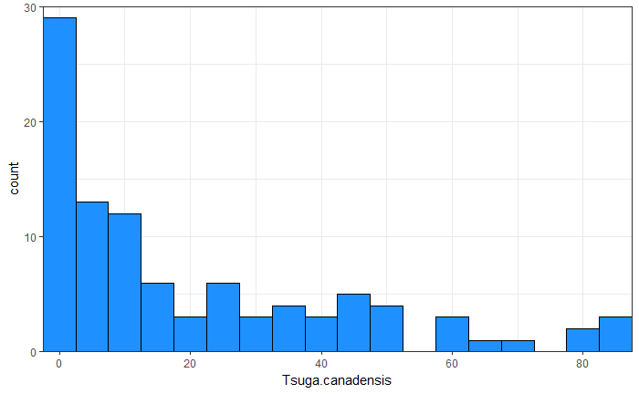

```r
ggplot(data = hemlock) +
  geom_histogram(aes(Tsuga.canadensis), binwidth = 5, colour = "black", fill = "dodgerblue") +
  coord_cartesian(ylim = c(0, 30), expand = FALSE) +
  theme_bw()
```

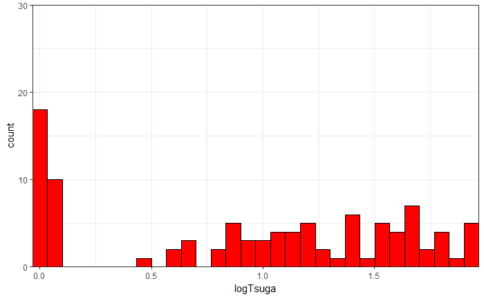

```r
ggplot(data = hemlock) +
  geom_histogram(aes(logTsuga), bins = 30, colour = "black", fill = "red") +
  coord_cartesian(ylim = c(0, 30), expand = FALSE) +
  theme_bw()
```

#### Power tranformations

- Square root transformation is most often used for Poisson type date (count data)
- Greater the power, the greater the compression of the data
- Flexible for a wide range of data
- Applied when the data is > 0

##### Write power function

```r
pwr_trans <- function(x, trans){
  x <- ifelse(x>0,x^(1/trans),0)
  return(x)
}
pwr_trans(25,2)
```

```
[1] 5
```

```r
pwr_trans(0,2)
```

```
[1] 0
```

#### Display the effect of the power function

```r
newdata <- data.frame(x = 0:100,
                      cubic = pwr_trans(x=0:100, trans = 3),
                      power10 = pwr_trans(x=0:100, trans = 10))
head(newdata)
```

|  | x | cubic | power10 |
| --- | --- | --- | --- |
| 1 | 0 | 0.000000 | 0.000000 |
| 2 | 1 | 1.000000 | 1.000000 |
| 3 | 2 | 1.259921 | 1.071773 |
| 4 | 3 | 1.442250 | 1.116123 |
| 5 | 4 | 1.587401 | 1.148698 |
| 6 | 5 | 1.709976 | 1.174619 |

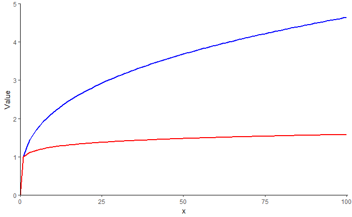

```r
ggplot(data = newdata) +
  geom_line(aes(x = x, y = cubic), size = 1, colour = "blue") +
  geom_line(aes(x = x, y = power10), size = 1, colour = "red") +
  labs(y = "Value") +
  coord_cartesian(xlim = c(0,100.5), ylim = c(0,5), expand = F)+
  theme_classic()
```

```r
NA
```

#### Presence absence transformation

- Transforms quantitative data to non-quanitative (binary)
- Applicable to species data
- Most useful when there is not a lot of quantitative data available (i.e., LOTS of zeros)
- Severe transformation (i.e., loose lots of information)

```r
library(vegan)
decostand(rawdata, method = "pa")
```

```
     species_A species_B species_C species_D species_E species_F
[1,]         1         1         1         1         1         1
[2,]         1         1         1         1         1         0
[3,]         1         1         1         1         1         0
[4,]         1         1         1         1         1         0
[5,]         0         0         0         1         0         0
attr(,"decostand")
[1] "pa"
```

#### Arcsine transformation

Please NOTE: [The arcsine is asinine: the analysis of proportions in ecology](http://onlinelibrary.wiley.com/doi/10.1890/10-0340.1/abstract)

- Transformations on proportion data (0-1)
- Useful when you have a positive skew in data
  - Spreads the end of the scale while compressing the middle

### Sums

- Can be applied to any range of x
- Output will range 0 - 1
- Converts values to a relative value (equalizes the area under the curve)
- Useful when you have large difference in total abundance

#### Rows

```r
ttl_species <- apply(rawdata, 1, sum)
rowprop_data <- rawdata / ttl_species

rowprop_data
```

```
     species_A species_B species_C species_D species_E species_F
[1,]       0.1       0.1       0.1       0.3       0.3       0.1
[2,]       0.1       0.1       0.2       0.3       0.3       0.0
[3,]       0.1       0.1       0.2       0.3       0.3       0.0
[4,]       0.3       0.3       0.2       0.1       0.1       0.0
[5,]       0.0       0.0       0.0       1.0       0.0       0.0
```

```r
decostand(rawdata, margin = 1, method = "total")
```

```
     species_A species_B species_C species_D species_E species_F
[1,]       0.1       0.1       0.1       0.3       0.3       0.1
[2,]       0.1       0.1       0.2       0.3       0.3       0.0
[3,]       0.1       0.1       0.2       0.3       0.3       0.0
[4,]       0.3       0.3       0.2       0.1       0.1       0.0
[5,]       0.0       0.0       0.0       1.0       0.0       0.0
attr(,"decostand")
[1] "total"
```

#### Columns

```r
colprop_data <- rawdata %*% diag(1/apply(rawdata,2,sum))
```

## Take home challenge

1. Input the data that Mike W. showed `mydata <- read_csv("https://ndownloader.figshare.com/files/2292169")`
2. Calculate the number of unique individuals per species per site per year per month for Rodents
3. Calculate the maximum number of unique individuals per species per site per year for Rodents
4. Calculate the max individuals across years per species per site for Rodents
5. Create a site by species matrix composed of those max values
6. Calculate by row total standardization
7. Plot a bar chart of each site and relative number of a few (3) species

Send to cchizinski2@unl.edu